# CLUSTERING

## 2 .Hierarchical Clustering

```
Distance Matrix:
[[ 0.    0.3   0.4   0.7   0.6 ]
 [ 0.3   0.    0.5   0.8   0.2 ]
 [ 0.4   0.5   0.    0.45  0.4 ]
 [ 0.7   0.8   0.45  0.    0.35]
 [ 0.6   0.2   0.4   0.35  0.  ]]
```

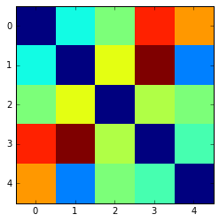

```python
%matplotlib inline
import numpy as np
import matplotlib.pyplot as plt
import pandas as pd
import scipy as sp
from scipy.cluster.hierarchy import dendrogram, linkage
from scipy.spatial import distance
dis_matrix=(0,0.3,0.4,0.7,0.6,0.3,0,0.5,0.8,0.2,0.4,0.5,0,0.45,0.4,0.7,0.8,0.45,0,0.35,0.6,0.2,0.4,0.35,0)
dissimilar=np.array(dis_matrix).reshape(5,5)
print "Distance Matrix:\n",dissimilar

plt.imshow(dissimilar, interpolation="nearest")

dissimilar = distance.squareform(dissimilar) #we can only pass upper triangular matrix.
                                             #Squareform gives n*(n-1)/2 vectors (upper traingular elements)
```

The 5 samples are numbered 0,1,2,3,4.

a)**Hierarchical Complete Linkage**

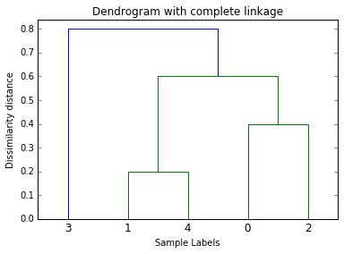

```python
thresholdC =0.8
linkageC = sp.cluster.hierarchy.linkage(dissimilar, method="complete")
clusterC = sp.cluster.hierarchy.fcluster(linkageC, thresholdC, criterion="distance")
# ClusterC gives the cluster labels for each sample

sp.cluster.hierarchy.dendrogram(linkageC, color_threshold=0.8)
plt.xlabel("Sample Labels")
plt.ylabel("Dissimilarity distance")
plt.title("Dendrogram with complete linkage")
plt.show()
```

1. Since 'complete' linkage takes the maximum distance between two points in different clusters, the maximum height goes upto 0.8 in the Dendrogram. This is the distance between samples labelled "1" and "3" (second and fourth samples).
2. The shortest height in the dendrogram is between samples labelled "1" and "4" (second and fifth respectively), which is 0.2 units and can be cross verified in the matrix as well.

b)**Hierarchical Single Linkage**

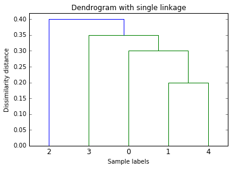

```python
thresholdS=0.5
linkageS = sp.cluster.hierarchy.linkage(dissimilar, method="single")
clusterS = sp.cluster.hierarchy.fcluster(linkageS, thresholdS, criterion="distance")


sp.cluster.hierarchy.dendrogram(linkageS,color_threshold=0.38)
plt.xlabel("Sample labels")
plt.ylabel("Dissimilarity distance")
plt.title("Dendrogram with single linkage")
plt.show()
```

**c)Cutting the dendrograms**

*Complete Linkage*

```python
# we will run some thresholds and calculate the cluster groupings
Tc=[0.3,0.4,0.5,0.6,0.7] #list of thresholds
cluster_complete=[]
for i in Tc:
    cluster_complete.append(sp.cluster.hierarchy.fcluster(linkageC,
                                                     i,
                                                   criterion="distance"))
```

```python
col=['0(sample1)','1(sample2)','2(sample3)','3(sample4)','4(sample5)']
groupC=pd.DataFrame(cluster_complete,index=('Cluster labels for thres=0.3',
                                            '0.4','0.5','0.6','0.7'),
                                                         columns=col)
GC=groupC.transpose()
print GC
```

```
            Cluster labels for thres=0.3  0.4  0.5  0.6  0.7
0(sample1)                             2    2    2    1    1
1(sample2)                             1    1    1    1    1
2(sample3)                             3    2    2    1    1
3(sample4)                             4    3    3    2    2
4(sample5)                             1    1    1    1    1
```

*Table of samples and their clusters*

The above table maps samples to their respective cluster labels for each threshold.  
from the above table we can see that for:  
threshold=0.3 , no of clusters=4 (clusters are labeled as 1,2,3 and 4)  
*threshold=0.4 , no of clusters=3*  
*threshold=0.5 , no of clusters=3*  
threshold=0.6 , no of clusters=2  
threshold=0.7 , no of clusters=2  
*Hence we can choose a threshold of 0.4 to cut the dendrogram to obtain 3 clusters*  
Sample 1 and sample 3 = cluster "2"  
Sample 2 and sample 5 = cluster "1"  
Sample 4 = cluster "3"

*Single Linkage*

```python
# we will run some thresholds and calculate the cluster groupings
Ts=[0.2,0.25,0.3,0.35,0.40] #list of thresholds
cluster_single=[]
for i in Ts:
    cluster_single.append(sp.cluster.hierarchy.fcluster(linkageS,
                                                     i,
                                                   criterion="distance"))

col=['0(sample1)','1(sample2)','2(sample3)','3(sample4)','4(sample5)']
groupS=pd.DataFrame(cluster_single,index=('Cluster labels for thres=0.2',
                                            '0.25','0.3','0.35','0.4'),
                                                         columns=col)
GS=groupS.transpose()
print GS
```

```
            Cluster labels for thres=0.2  0.25  0.3  0.35  0.4
0(sample1)                             2     2    1     1    1
1(sample2)                             1     1    1     1    1
2(sample3)                             4     4    3     2    1
3(sample4)                             3     3    2     1    1
4(sample5)                             1     1    1     1    1
```

*Table of samples and their clusters*

The above table maps samples to their respective cluster labels for each threshold.  
from the above table we can see that for:  
threshold=0.2 , no of clusters=4 (clusters are labeled as 1,2,3 and 4)  
threshold=0.25 , no of clusters=4  
*threshold=0.3, no of clusters=3*  
threshold=0.35 , no of clusters=2  
threshold=0.4 , no of clusters=1  
*Hence we can choose a threshold of 0.3 to cut the dendrogram to obtain 3 clusters*  
Sample 1,sample 2,sample 5 = cluster "1"  
Sample 3= cluster "3"  
Sample 4 = cluster "2"

# 3) College Data

```python
%matplotlib inline
import sklearn as sk
import pandas as pd
from sklearn import metrics
from sklearn import decomposition
import matplotlib.pyplot as plt
import numpy as np
import scipy as sp
from scipy.cluster.hierarchy import dendrogram, linkage
from scipy.spatial import distance
from sklearn import preprocessing
college_num=np.loadtxt('collegep4.csv',delimiter=',',skiprows=1,
                       usecols=np.arange(3,17)) #considering only numerical columns(3-16)
college_num.shape
```

```
(20L, 14L)
```

```python
from scipy.stats import zscore
scaled_college=zscore(college_num)
```

We are using Zscore scaler to tranform the data set into normalized values which is ideal for clustering because we need to compare similarities between samples based on distances. Hence this has to be done before dissimilar matrix calculation.We are also interested in standardization which accurately represents the maximum variance especially useful for Principal component analysis later. If we use min max scaling, we might supress the variance and may include outliers within our scaling limits. Hence we prefer Zscore normalization for better clustering analysis.

```python
#Dissimilar matrix using scaled data
dissimilar_scaled=sp.spatial.distance.pdist(scaled_college, metric='euclidean')
dissimilar_scaled.shape
```

```
(190L,)
```

We have 20 samples, hence our dissimilar matrix has to be a symmetric 20x20 matrix. The above 'spatial distance pdist' function gives us n*(n-1)/2 vectors=190, which is the upper triangular matrix elements of the 20x20 dissimilar matrix.

### a) Agglomerative Hierarchical Clustering Complete linkage

```python
collegenames=pd.read_csv('collegep4.csv',sep=',',header=0,usecols=np.arange(2,3))
univs=collegenames['Name'].values.tolist()
univs
```

```
['CalPoly',
 'CMU',
 'Cornell',
 'GeorgiaTech',
 'MIT',
 'NYU',
 'Rutgers',
 'SJSU',
 'Stanford',
 'UT-Austin',
 'UC-Berkeley',
 'UC-Irvine',
 'UCLA',
 'UCSD',
 'UCSB',
 'UIUC',
 'UMD',
 'UW',
 'VirginiaTech',
 'WPI']
```

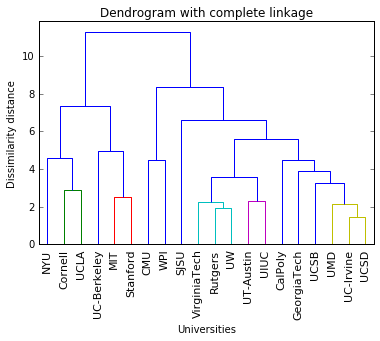

```python
thres_C =1
linkage_C = sp.cluster.hierarchy.linkage(dissimilar_scaled, method="complete")
cluster_C = sp.cluster.hierarchy.fcluster(linkage_C, thres_C, criterion="distance")
# ClusterC gives the cluster labels for each sample

sp.cluster.hierarchy.dendrogram(linkage_C, color_threshold=3,labels=univs,leaf_rotation=90,leaf_font_size=11)
plt.xlabel("Universities")
plt.ylabel("Dissimilarity distance")
plt.title("Dendrogram with complete linkage")
plt.show()
```

### b)Remove some schools - perform Hierarchical Clustering

```python
#univs to remove=("CalPoly", "NYU", "Rutgers","SJSU", "UCSD", "UCSB","WPI")
for i, j in enumerate(univs):
    print i,j
```

```
0 CalPoly
1 CMU
2 Cornell
3 GeorgiaTech
4 MIT
5 NYU
6 Rutgers
7 SJSU
8 Stanford
9 UT-Austin
10 UC-Berkeley
11 UC-Irvine
12 UCLA
13 UCSD
14 UCSB
15 UIUC
16 UMD
17 UW
18 VirginiaTech
19 WPI
```

```python
rindex=[0,5,6,7,13,14,19]
college_updated=np.delete(college_num,rindex,axis=0)
print college_updated.shape
```

```
(13L, 14L)
```

### Complete Linkage

```python
#Scaling using Minmax scaler in the range (0,1)

minmaxC=preprocessing.MinMaxScaler(feature_range=(0,1))
scaled_updatedcollege=minmaxC.fit_transform(college_updated)

#Dissimilar matrix using scaled data
dissimilar_scaled_updated=sp.spatial.distance.pdist(scaled_updatedcollege, metric='euclidean')
dissimilar_scaled_updated.shape
```

```
(78L,)
```

We have 13 samples. Dissimilar matrix would be 13x13. The upper triangular elements would be 13*12/2 = 78

```python
#updated college list labels:
updated_univs = [x for i,x in enumerate(univs) if i not in rindex]
print updated_univs
```

```
['CMU', 'Cornell', 'GeorgiaTech', 'MIT', 'Stanford', 'UT-Austin', 'UC-Berkeley', 'UC-Irvine', 'UCLA', 'UIUC', 'UMD', 'UW', 'VirginiaTech']
```

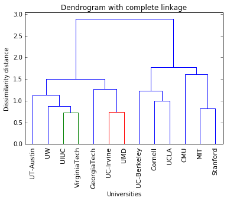

```python
# Dendrogram
threshold_CC =1
linkage_CC = sp.cluster.hierarchy.linkage(dissimilar_scaled_updated, method="complete")
cluster_CC = sp.cluster.hierarchy.fcluster(linkage_CC, threshold_CC, criterion="distance")


sp.cluster.hierarchy.dendrogram(linkage_CC, color_threshold=0.8,labels=updated_univs,leaf_rotation=90,leaf_font_size=11)
plt.xlabel("Universities")
plt.ylabel("Dissimilarity distance")
plt.title("Dendrogram with complete linkage")
plt.show()
```

### Average Linkage

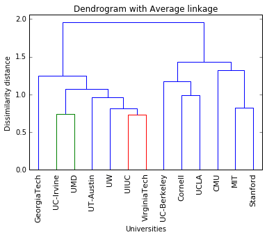

```python
# Dendrogram
threshold_CAVG =1
linkage_CAVG = sp.cluster.hierarchy.linkage(dissimilar_scaled_updated, method="average")
cluster_CAVG = sp.cluster.hierarchy.fcluster(linkage_CAVG, threshold_CAVG, criterion="distance")


sp.cluster.hierarchy.dendrogram(linkage_CAVG, color_threshold=0.8,labels=updated_univs,leaf_rotation=90,leaf_font_size=11)
plt.xlabel("Universities")
plt.ylabel("Dissimilarity distance")
plt.title("Dendrogram with Average linkage")
plt.show()
```

### c) Single linkage

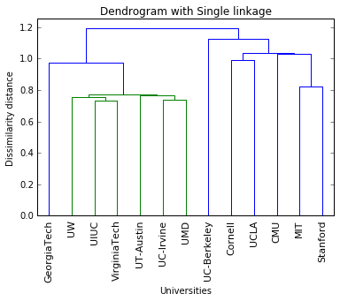

```python
# Dendrogram
threshold_CS =1
linkage_CS = sp.cluster.hierarchy.linkage(dissimilar_scaled_updated, method="single")
cluster_CS = sp.cluster.hierarchy.fcluster(linkage_CS, threshold_CS, criterion="distance")
# ClusterCS gives the cluster labels for each sample

sp.cluster.hierarchy.dendrogram(linkage_CS, color_threshold=0.8,labels=updated_univs,leaf_rotation=90,leaf_font_size=11)
plt.xlabel("Universities")
plt.ylabel("Dissimilarity distance")
plt.title("Dendrogram with Single linkage")
plt.show()
```

```python
# we will run some thresholds and calculate the cluster groupings
TCS=[0.7,0.8,0.9,1,1.05] #list of thresholds
cluster_csingle=[]
for i in TCS:
    cluster_csingle.append(sp.cluster.hierarchy.fcluster(linkage_CS,
                                                     i,
                                                   criterion="distance"))

groupCS=pd.DataFrame(cluster_csingle,index=('Cluster labels for thres=0.7',
                                            '0.8','0.9','1','1.05'),
                                                         columns=updated_univs)
GCS=groupCS.transpose()
print GCS
```

```
              Cluster labels for thres=0.7  0.8  0.9  1  1.05
CMU                                     12    7    6  4     2
Cornell                                  8    3    3  2     2
GeorgiaTech                              7    2    2  1     1
MIT                                     10    5    5  3     2
Stanford                                11    6    5  3     2
UT-Austin                                6    1    1  1     1
UC-Berkeley                             13    8    7  5     3
UC-Irvine                                4    1    1  1     1
UCLA                                     9    4    4  2     2
UIUC                                     1    1    1  1     1
UMD                                      5    1    1  1     1
UW                                       3    1    1  1     1
VirginiaTech                             2    1    1  1     1
```

**Table of samples and their clusters**

It can be seen from the table that the ideal distance/length to cut the dendrogram for single linkage to obtain three clusters is **height=1.05**  
**Cluster 1 contains:** GeorgiaTech,UT-Austin,UC-Irvine,UIUC,UMD,UW,VirginiaTech  
**Cluster 2 contains:** CMU,Cornell,MIT,Stanford,UCLA  
**Cluster 3 contains:** UC-Berkeley

### d) Principal Component Analysis

```python
pca=sk.decomposition.PCA(n_components=2)
pca_f=pca.fit (scaled_college)
pca_t=pca_f.transform(scaled_college)

first=pca_f.components_[0] #coefficient for component 1
second=pca_f.components_[1] # coefficient for component 2

scaled_college.shape
```

```
(20L, 14L)
```

```python
print pca_f.explained_variance_ratio_
```

```
[ 0.45817836  0.19292177]
```

**The above two values belong to variance in each of the two selected principal component directions. We can see that component1 which is the major principal component has more variance, 0.458 which means that all the data points projected on this principal axis will retain the maximum information.**

```python
temp=scaled_college
print temp.shape
```

```
(20L, 14L)
```

```python
cole=pd.read_csv('collegep4.csv',sep=',',usecols=np.arange(3,17))
cscaled=zscore(cole)
ca=cscaled.mean(axis=0)
```

```python
ca
```

```
array([ -1.82076576e-15,  -3.77475828e-16,  -6.04377659e-16,
        -1.33226763e-16,  -2.30371278e-16,  -8.32667268e-18,
        -1.97064587e-16,   2.22044605e-16,   1.66533454e-17,
        -1.44328993e-16,  -1.22124533e-16,  -6.66133815e-17,
        -1.52655666e-17,   1.11022302e-17])
```

```python
####Center the data
for i in range(0,14):
    for j in range(0,20):
        temp[j,i]=temp[j,i]-ca[i]
```

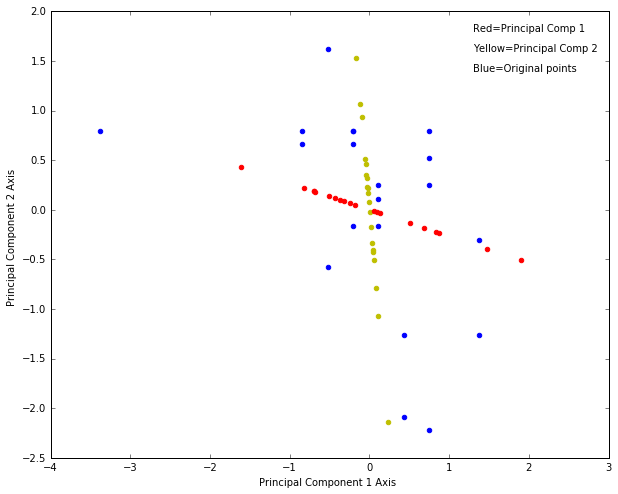

```python
##
comp1=[]
comp2=[]
plt.figure(figsize=(10,8))
for tra,ori in zip(pca_t,temp):
    plt.scatter(first[0]*tra[0],first[1]*tra[0],color='r')
    plt.scatter(second[0]*tra[1],second[1]*tra[1],color='y')
    plt.scatter(ori[0],ori[1],color='b')

plt.text(1.3,1.8,'Red=Principal Comp 1')
plt.text(1.3,1.6,'Yellow=Principal Comp 2')
plt.text(1.3,1.4,'Blue=Original points')
plt.xlabel("Principal Component 1 Axis ")
plt.ylabel("Principal Component 2 Axis ")
```

The above plot shows original data which is in blue along with the two principal components. The principal components are orthogonal to each other.Due to scaling we may not visualise the orthogonality here. The 'Red' points indicate the major Principal component along which the data has largest variance or spread. The yellow principal compoenent is the minor one that is parpendicular to the major component and has minimum variance. We had 20 samples with 14 dimensions but after PCA we have just two dimensions. The PCA algorithm choses major principal component based on how much efficiently maximum data can be conserved.

### e)K-Means Clustering

```python
from sklearn.cluster import KMeans
#CLustering to be performed on modified list of univeristies
kms=KMeans(n_clusters=3,random_state=99)
kms_f=kms.fit(college_updated)
labels = kms.labels_
```

```python
kmst=pd.DataFrame(labels,index=(updated_univs),columns=['KMeans Labels'])

KMsorted=kmst.sort_values(by=['KMeans Labels'], ascending=True)
print KMsorted
```

```
              KMeans Labels
CMU                       0
Cornell                   0
UC-Berkeley               0
UCLA                      0
GeorgiaTech               1
UT-Austin                 1
UC-Irvine                 1
UIUC                      1
UMD                       1
UW                        1
VirginiaTech              1
MIT                       2
Stanford                  2
```

The above table shows which colleges are clustered together.

```python
#gcs_sorted=GCS.sort_values(['1.05'],ascending=True)
#gcs_sorted['1.05']
Hierarchcal_single_labels=(2,2,3,2,1,1,1,1,1,1,1,2,2)
KMeans_cluster_labels=labels

KMsorted['Single-Linkage Labels']=Hierarchcal_single_labels
print KMsorted
```

```
              KMeans Labels  Single-Linkage Labels
CMU                       0                      2
Cornell                   0                      2
UC-Berkeley               0                      3
UCLA                      0                      2
GeorgiaTech               1                      1
UT-Austin                 1                      1
UC-Irvine                 1                      1
UIUC                      1                      1
UMD                       1                      1
UW                        1                      1
VirginiaTech              1                      1
MIT                       2                      2
Stanford                  2                      2
```

0,1,2,3 are just labels or names. '1' in KMeans is not the same as '1' in Single Linkage. These clusters just indicate that the  
universities belong to that group. These elements/Univs are clustered together as groups and have been assigned some random numbers as names.

*Observations:*

1. KMeans and Single Linkage Hierarchichal Clustering have different results. Even though many universities have similar clustering, some are different. This may be because of the way each algorithms work. Kmeans clustering highly depend upon the initial choice of centroids.
2. The three groups have different sizes as well.
3. For instance, UC Berkeley is a seperate group in itself based on Single linkage Clustering but it groups with CMU,Cornell etc in cluster labelled '0' based on KMeans Clustering.

# 4) Music Data

```python
music_num=np.loadtxt('musicp4.csv',delimiter=',',skiprows=1,
                       usecols=np.arange(3,8)) #considering only numerical columns(3-7)
music_num.shape
```

```
(62L, 5L)
```

Since we are clustering hierarchically , we need to compute dissimilar matrix. We need Z score transformation of data to give us a sensible value for the distances. Also the Zscore does not supress the outliers in the data. Hence it is favorable to use Zscore transformation than Minmax for clustering.

```python
#Z score transformation of data:
from scipy.stats import zscore
scaled_music=zscore(music_num)
scaled_music.shape
```

```
(62L, 5L)
```

```python
#Dissimilar matrix using scaled data
dis_scaled=sp.spatial.distance.pdist(scaled_music, metric='euclidean')
dis_scaled.shape
```

```
(1891L,)
```

These 1891 points are the upper triangular Dissimilar matrix of 62x62 size

### Single Linkage Hierarchical Clustering

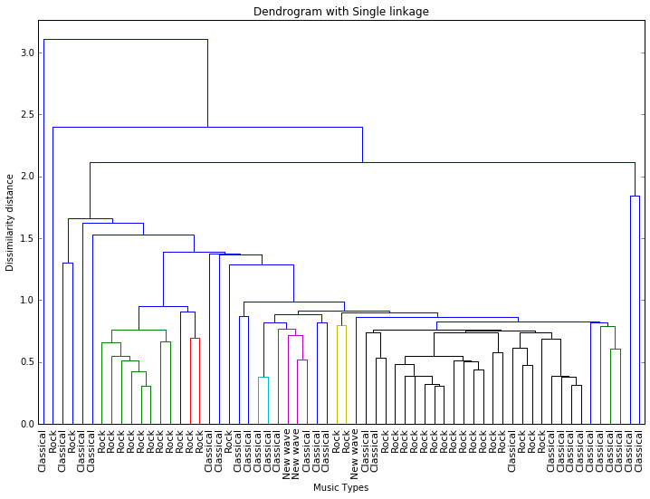

```python
# Dendrogram
musicg=pd.read_csv('musicp4.csv',sep=',',header=0,usecols=np.arange(2,3))
mtype=musicg['Type'].values.tolist()

linkage_MS = sp.cluster.hierarchy.linkage(dis_scaled, method="single")


plt.figure(figsize=(12,8))
sp.cluster.hierarchy.dendrogram(linkage_MS, color_threshold=0.8,labels=mtype,leaf_font_size=11)
plt.xlabel("Music Types")
plt.ylabel("Dissimilarity distance")
plt.title("Dendrogram with Single linkage")
plt.show()
```

from the Dendrogram we can see that for three clusters, we can cut the dendrogram at a height close to 2.5. We can arbitarily choose the value to be 2.3 and check the resulting cluster labels.

```python
#Dendrogram cutting the clusters

t_MS =2.3
cluster_MS = sp.cluster.hierarchy.fcluster(linkage_MS, t_MS, criterion="distance")
print cluster_MS
```

```
[1 1 1 1 1 1 1 1 1 1 1 1 1 1 1 3 1 1 1 1 1 1 1 1 1 1 1 2 1 1 1 1 1 1 1 1 1
 1 1 1 1 1 1 1 1 1 1 1 1 1 1 1 1 1 1 1 1 1 1 1 1 1]
```

## Complete Linkage

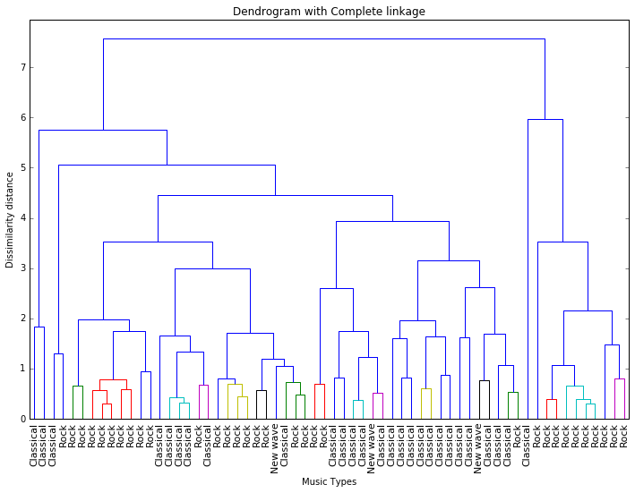

```python
# Dendrogram

linkage_MC = sp.cluster.hierarchy.linkage(dis_scaled, method="complete")

plt.figure(figsize=(12,8))
sp.cluster.hierarchy.dendrogram(linkage_MC, color_threshold=0.8,labels=mtype,leaf_font_size=11)
plt.xlabel("Music Types")
plt.ylabel("Dissimilarity distance")
plt.title("Dendrogram with Complete linkage")
plt.show()
```

```python
# Cutting the Dedrogram for clusters
t_MC =5.8
cluster_MC = sp.cluster.hierarchy.fcluster(linkage_MC, t_MC, criterion="distance")
print cluster_MC
```

```
[1 1 1 1 1 1 1 1 1 1 1 1 1 1 1 3 1 1 1 1 1 1 1 1 1 1 1 2 1 1 2 1 2 1 2 1 1
 2 2 2 2 2 1 1 1 2 1 1 1 1 1 1 1 1 1 1 1 1 1 1 1 1]
```

Looking at the dedrogram we can concude that we can choose a height approximately less 6 to obtain three clusters of data. Since we actually have only 3 genre of music here we can cut it at say 5.8 to obtain three clusters. But the clusters are not totally clustered correctly.

## Analysis with Label 'Artist'

### Single Linkage

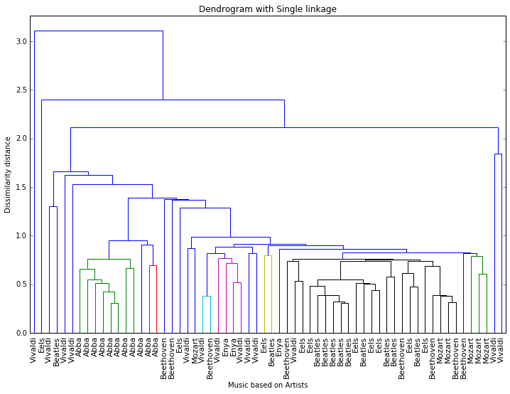

```python
# Dendrogram
musica=pd.read_csv('musicp4.csv',sep=',',header=0,usecols=np.arange(1,2))
mart=musica['Artist'].values.tolist()
linkage_AS = sp.cluster.hierarchy.linkage(dis_scaled, method="single")


plt.figure(figsize=(12,8))
sp.cluster.hierarchy.dendrogram(linkage_AS, color_threshold=0.8,labels=mart,leaf_font_size=11)
plt.xlabel("Music based on Artists")
plt.ylabel("Dissimilarity distance")
plt.title("Dendrogram with Single linkage")
plt.show()
```

```python
musica.Artist.unique()
```

```
array(['Abba', 'Vivaldi', 'Mozart', 'Eels', 'Beatles', 'Beethoven', 'Enya'], dtype=object)
```

We can see that there are 7 different artists hence we can cut the dendrogram to form 7 different clusters ideally representing the correct mapping of artists with the song clusters.

```python
# Cutting the Dedrogram for clusters
t_AS =1.6
cluster_AS = sp.cluster.hierarchy.fcluster(linkage_AS, t_AS, criterion="distance")
print cluster_AS
```

```
[2 2 2 2 2 2 2 2 2 2 2 4 3 2 1 7 5 2 2 2 2 2 2 2 2 2 2 6 2 2 2 2 2 2 2 2 2
 2 2 2 2 2 2 2 2 2 2 2 2 2 2 2 2 2 2 2 2 2 2 2 2 1]
```

From the dedrogram we can cut at the height close to 1.5. Cutting at 1.6 yeilds exactly 7 different clusters as seen from the above matrix with the list of the cluster labels with maximum label being '7'.

## Complete Linkage

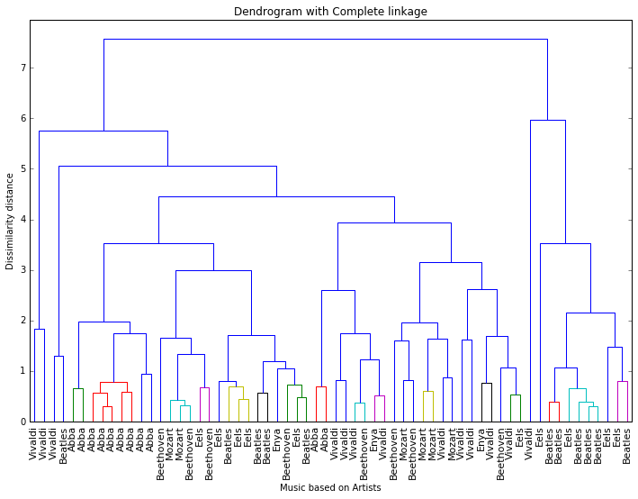

```python
# Dendrogram
linkage_AC = sp.cluster.hierarchy.linkage(dis_scaled, method="complete")


plt.figure(figsize=(12,8))
sp.cluster.hierarchy.dendrogram(linkage_AC, color_threshold=0.8,labels=mart,leaf_font_size=11)
plt.xlabel("Music based on Artists")
plt.ylabel("Dissimilarity distance")
plt.title("Dendrogram with Complete linkage")
plt.show()
```

```python
# Cutting the Dedrogram for clusters
t_AC=3.7
cluster_AC = sp.cluster.hierarchy.fcluster(linkage_AC, t_AC, criterion="distance")
print cluster_AC
```

```
[3 3 3 3 3 3 4 4 3 3 5 1 5 4 2 7 1 4 5 5 5 5 3 5 5 3 3 6 3 3 6 3 6 5 6 3 3
 6 6 6 6 6 3 3 3 6 3 4 3 3 5 5 5 3 4 3 5 3 4 4 5 2]
```

If we cut the dendrogram approximately around 4 , say 3.7, we get the number of clusters as 7.

### Complete vs Single Linkage

```python
# Complete Linkage
from scipy import stats
print "    ", "Labels",  "counts"
stats.itemfreq(cluster_AC)
```

```
     Labels counts
```

```
array([[ 1,  2],
       [ 2,  2],
       [ 3, 25],
       [ 4,  8],
       [ 5, 14],
       [ 6, 10],
       [ 7,  1]], dtype=int64)
```

*Complete Linkage*

```python
#Single Linkage
print "    ", "Labels",  "counts"
stats.itemfreq(cluster_AS)
```

```
     Labels counts
```

```
array([[ 1,  2],
       [ 2, 55],
       [ 3,  1],
       [ 4,  1],
       [ 5,  1],
       [ 6,  1],
       [ 7,  1]], dtype=int64)
```

*Single Linkage*

Single vs Complete linkages  
The above arrays represent the cluster labels in the first column and the number of samples in the second column.  
Comparing both the tables, we can see that single linkage clustering has grouped too many samples (majority) under the label "2" ,  
While actually there are 6 other artists and almost they have no songs under them. This clustering is not very effective. The farther elements belonging to the same cluster are closer to the elements of other clusters, hence there is a good chance of these farther elements being misclassfied and mapped to the wrong cluster. This is the reason we cannot properly divide the data and spread them out in other clusters.Hence we can say that, observing the number of elements(songs) clustered under each artists , Complete linkage clustering is effective and reliable than the single linkage.